# R Notebook

**Please prepare a 1 to 2 page analysis summary answering the question below.**

**In order to help inform the planning for provision of cancer treatment services in NHS Borders, we would like to gain better understanding of the incidence of cancer in NHS Borders.**

**You will present your findings back to us during the Mock Interviews. Presentations will be 5 minutes long**

**Remember** “A better understanding of the incidence of cancer in NHS Borders”

1. Find the definition of incidence in the documentation provided:

“Incidence is the total number of new cases (registrations) of the cancer diagnosed in Scotland for the given period.”

2. Next, which insights could be *actionable*. Focus on these.

The question refers to the helping “inform the planning for *provision* of cancer service in NHS Borders”. This should be the focus for insights that are actionable:

Geographic considerations should be taken into account. Where are the higher incidents of certain types of treatment.

Where are current cancer treatment services available

How can services be improved for those suffering from cancer in the area, given the number of incidence.

```r
library(tidyverse)
library(janitor)
health_board_data <- read_csv("data/opendata_inc9418_hb.csv") %>% clean_names()
scotland_data <- read_csv("data/opendata_inc9418_scotland.csv") %>% clean_names()
regional_data <- read_csv("data/opendata_inc9418_region.csv") %>%  clean_names()
hb_codes <- read_csv("data/geography_codes_and_labels_hb2014_01042019.csv") %>% clean_names()
```

Let’s take a look at the number of these columns and work out how many we have and how they should be organised from here.

```r
health_board_data %>%
  colnames()
```

OK, so what becomes immedietely apparent is that the data doesn’t seem to be broken down into age group. Instead, we are only given an incidences_all_ages column, along with wath is described as a “crude rate”. For a task in this timeframe, with one person non-technical interviewing and with five minutes to talk about, I don’t think it would be useful to go to deeply into the confidence intervals at this stage. If we are struggling for useful (i.e. *actionable*) insights, then using some of these 95 confidence intervals could be good as a last resort.

What we do have is a breakdown of different types of cancer, and a breakdown in terms of the sexes. We should be able to get some insights here, but what conclusions could be drawn linking back to the “planning for provision of cancer treatment services in NHS Borders”. We might have to compare rates to that of surrounding health boards, the overall region and Scotland as a whole. Think it might be best to just play about with this first lot of data tonight though and see if there are any striking figures in terms of types of cancer over the years.

```r
borders_data <-
health_board_data %>%
  filter(hb == "S08000016")
```

So once we extract just the NHS borders data, what we find are left with is 3400 observations. Now let’s see how many cancer types we’re dealing with:

```r
borders_data %>%
  distinct(cancer_site)
```

| cancer_site |
| --- |
| All cancer types |
| Bladder |
| Bone and articular cartilage |
| Bone and connective tissue |
| Connective tissue |
| Malignant brain cancer |
| Malig brain ca (incl pit. gland, cranio. duct, pineal gland) |
| Non-malig brain ca (incl pit.gland,cranio.duct,pineal gland) |
| All brain and CNS tumours (malignant and non-malignant) |
| Breast |

[output cut: 42 more lines]

So we have 52 cancer sites/types, including an “All cancer types” label.

```r
borders_data %>%
  distinct(sex_qf)
```

[output not shown]

According to the accompanying documentation, “Confidence intervals for age-standardised rates (EASR and WASR) have been calculated using a formula which works only when numbers are sufficiently large. They are therefore set to ‘not applicable’ in the event of there being fewer than 20 cases.”

```r
borders_data %>%
  summarise(across(.fns = ~sum(is.na(.x))))
```

| hb | cancer_site_icd10code | cancer_site | sex | sex_qf | year | incidences_all_ages | crude_rate | crude_rate_lower95pc_confidence_interval | crude_rate_upper95pc_confidence_interval | easr | easr_lower95pc_confidence_interval | easr_lower95pc_confidence_interval_qf | easr_upper95pc_confidence_interval | easr_upper95pc_confidence_interval_qf | wasr | wasr_lower95pc_confidence_interval | wasr_lower95pc_confidence_interval_qf | wasr_upper95pc_confidence_interval | wasr_upper95pc_confidence_interval_qf | standardised_incidence_ratio | sir_lower95pc_confidence_interval | sir_upper95pc_confidence_interval |
| --- | --- | --- | --- | --- | --- | --- | --- | --- | --- | --- | --- | --- | --- | --- | --- | --- | --- | --- | --- | --- | --- | --- |
| 0 | 0 | 0 | 0 | 2350 | 0 | 0 | 0 | 0 | 0 | 0 | 2535 | 865 | 2535 | 865 | 0 | 2535 | 865 | 2535 | 865 | 0 | 0 | 0 |

So there don’t seem to be any observations that are relvant to our early analysis that are NAs. There do seem to be a number of NAs in the “sex_qf” column which I’m still a little confused on, the alternative simply being “d”. The NAs referenced above can also be seen.

Let’s just see if we can begin by plotting the differnt types of cancer and their prevalence by both number an rate.

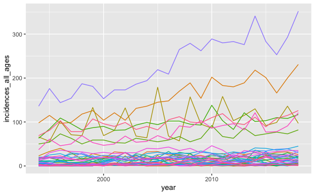

```r
borders_data %>%
filter(cancer_site != "All cancer types",
       sex == "All") %>%
ggplot() +
  aes(x = year, y = incidences_all_ages, color = cancer_site) +
  geom_line() +
  theme(legend.position = "none")
```

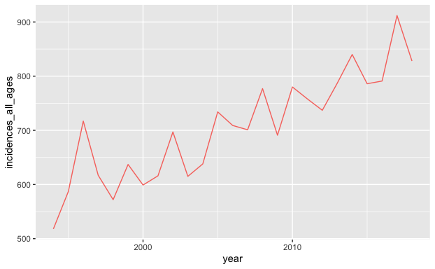

```r
borders_data %>%
filter(cancer_site == "All cancer types",
       sex == "All") %>%
ggplot() +
  aes(x = year, y = incidences_all_ages, color = cancer_site) +
  geom_line() +
  theme(legend.position = "none")
```

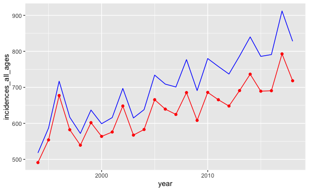

```r
borders_data %>%
filter(cancer_site == "All cancer types",
       sex == "All") %>%
ggplot() +
  geom_line(aes(x = year, y = incidences_all_ages), colour = "blue") +
  geom_point(aes(x = year, y = crude_rate), colour = "red") +
  geom_line (aes(x = year, y = crude_rate), colour = "red")
```

```r
# borders_data %>%
#  mutate(total_incidences = )
```

```r
borders_data %>%
  distinct(year)
```

| year |
| --- |
| 1994 |
| 1995 |
| 1996 |
| 1997 |
| 1998 |
| 1999 |
| 2000 |
| 2001 |
| 2002 |
| 2003 |

[output cut: 15 more lines]

Right, the above idea can be left for later. For now, I want to replicate three graphs that have been provided for the overall Scottish context. These graphs are contained in the Cancer Incidence in Scotland (2016) report. Here is the plan (refer back to the document for visual reference):

1. Cancer incidence in Scotland, 1992-2016. Number of cases and age-adjusted incidence rate by sex.

**Note on trends** **It may be misleading to focus too much attention on any apparent changes in incidence between 2015 and 2016; it is more informative to examine trends in incidence observed over a number of years. Striking changes from one year to the next may occur in the case of rare cancers, but these are likely to reflect random fluctuation caused by small numbers of cases - in such cases, it is even more important to examine incidence rates for a number of years aggregated together, rather than focusing on a single year of incidence**

**The number and type of cancer registrations, by sex and geography, allow planning for provision of cancer treatment services and palliative care planning. Permits indirect measure of success of public health measures and interventions over the longer term. Key uses include: public health surveillance; health needs assessment, planning and commissioning of cancer services; evaluation of the impact of interventions on incidence and survival; clinical audit and health services research; epidemiological studies; and providing information to support genetic counselling and health promotion.**

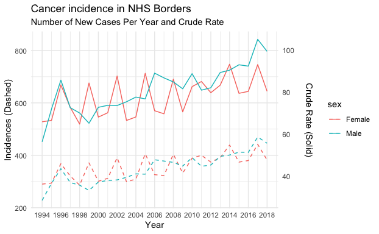

```r
#These graphs can be easily changed later on to accommodate other rates, especially when we look a bit further into the easr and wasr rates.
borders_data %>%
  filter(cancer_site == "All cancer types",
         sex != "All") %>%
ggplot() +
  geom_line(aes(x = year, y = incidences_all_ages, colour = sex), linetype = "dashed") +
  geom_line(aes(x = year, y = crude_rate, colour = sex)) +
  scale_x_continuous(breaks = seq(1994, 2018, by = 2 )) +
  scale_y_continuous(sec.axis = sec_axis(~./8, name = "Crude Rate (Solid)\n")) +
  labs(x = "Year",
       y = "Incidences (Dashed)",
       title = "Cancer incidence in NHS Borders",
       subtitle = "Number of New Cases Per Year and Crude Rate") +
  theme_minimal()
```

```r
  #theme(legend.title = element_text(size = 4)) +
  #scale_linetype_manual(name = "a")
  #Can't work out why the legend below isn't working
  #scale_fill_discrete(name = "Sex", labels = c("a", "b")) +
```

```r
borders_data %>%
  filter(sex == "Female")
```

| hb | cancer_site_icd10code | cancer_site | sex | sex_qf | year | incidences_all_ages | crude_rate | crude_rate_lower95pc_confidence_interval | crude_rate_upper95pc_confidence_interval | easr | easr_lower95pc_confidence_interval | easr_lower95pc_confidence_interval_qf | easr_upper95pc_confidence_interval | easr_upper95pc_confidence_interval_qf | wasr | wasr_lower95pc_confidence_interval | wasr_lower95pc_confidence_interval_qf | wasr_upper95pc_confidence_interval | wasr_upper95pc_confidence_interval_qf | standardised_incidence_ratio | sir_lower95pc_confidence_interval | sir_upper95pc_confidence_interval |
| --- | --- | --- | --- | --- | --- | --- | --- | --- | --- | --- | --- | --- | --- | --- | --- | --- | --- | --- | --- | --- | --- | --- |
| S08000016 | C00-C97, excluding C44 | All cancer types | Female | NA | 1994 | 290 | 527.858170 | 468.84731217 | 592.241078 | 499.807289 | 443.32138 | NA | 559.63118 | NA | 238.1513437 | 206.910847 | NA | 271.55625 | NA | 93.45863 | 83.0106038 | 104.85778 |
| S08000016 | C00-C97, excluding C44 | All cancer types | Female | NA | 1995 | 294 | 533.284963 | 474.06232808 | 597.860337 | 511.629930 | 454.24532 | NA | 572.37842 | NA | 245.3585211 | 213.818448 | NA | 279.03678 | NA | 93.45605 | 83.0775228 | 104.77263 |
| S08000016 | C00-C97, excluding C44 | All cancer types | Female | NA | 1996 | 368 | 668.483197 | 601.92061527 | 740.395458 | 638.982087 | 574.76476 | NA | 706.55118 | NA | 322.0680191 | 284.560521 | NA | 361.86384 | NA | 111.42758 | 100.3324537 | 123.41444 |
| S08000016 | C00-C97, excluding C44 | All cancer types | Female | NA | 1997 | 321 | 582.852163 | 520.82814211 | 650.229982 | 549.308039 | 490.37165 | NA | 611.54056 | NA | 264.1662692 | 230.946164 | NA | 299.58614 | NA | 99.25210 | 88.6902183 | 110.72566 |
| S08000016 | C00-C97, excluding C44 | All cancer types | Female | NA | 1998 | 286 | 519.093945 | 460.67060608 | 582.874741 | 489.033607 | 433.64384 | NA | 547.70423 | NA | 239.4579846 | 207.397376 | NA | 273.78911 | NA | 90.69832 | 80.4903432 | 101.84237 |
| S08000016 | C00-C97, excluding C44 | All cancer types | Female | NA | 1999 | 371 | 675.971139 | 608.92850329 | 748.379264 | 645.817749 | 581.40634 | NA | 713.56415 | NA | 336.6534407 | 298.272718 | NA | 377.32340 | NA | 116.74021 | 105.1619456 | 129.24509 |
| S08000016 | C00-C97, excluding C44 | All cancer types | Female | NA | 2000 | 301 | 545.823813 | 485.89694139 | 611.100680 | 510.009948 | 453.71672 | NA | 569.54745 | NA | 237.1603580 | 206.805613 | NA | 269.56344 | NA | 92.97632 | 82.7683009 | 104.09566 |
| S08000016 | C00-C97, excluding C44 | All cancer types | Female | NA | 2001 | 312 | 562.334409 | 501.66140467 | 628.323133 | 529.357500 | 471.89521 | NA | 590.07342 | NA | 268.2269248 | 235.179066 | NA | 303.41583 | NA | 97.45394 | 86.9391585 | 108.88995 |
| S08000016 | C00-C97, excluding C44 | All cancer types | Female | NA | 2002 | 391 | 702.517204 | 634.60102364 | 775.722021 | 660.882452 | 596.68679 | NA | 728.31077 | NA | 344.2732230 | 306.163504 | NA | 384.58603 | NA | 120.44926 | 108.8047685 | 133.00050 |
| S08000016 | C00-C97, excluding C44 | All cancer types | Female | NA | 2003 | 299 | 533.014832 | 474.30461627 | 596.984769 | 489.956467 | 435.60727 | NA | 547.45444 | NA | 229.8027724 | 199.913954 | NA | 261.74346 | NA | 89.77116 | 79.8830979 | 100.54507 |

[output cut: 990 more lines]

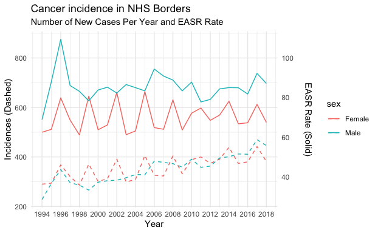

```r
borders_data %>%
  filter(cancer_site == "All cancer types",
         sex != "All") %>%
ggplot() +
  geom_line(aes(x = year, y = incidences_all_ages, colour = sex), linetype = "dashed", show.legend = TRUE) +
  geom_line(aes(x = year, y = easr, colour = sex), show.legend = TRUE) +
  scale_x_continuous(breaks = seq(1994, 2018, by = 2 )) +
  scale_y_continuous(sec.axis = sec_axis(~./8, name = "EASR Rate (Solid)\n")) +
  labs(x = "Year",
       y = "Incidences (Dashed)",
       title = "Cancer incidence in NHS Borders",
       subtitle = "Number of New Cases Per Year and EASR Rate") +
  #Can't work out why the legend below isn't working
  #scale_fill_discrete(name = "Sex", labels = c("a", "b")) +
  theme_minimal()
```

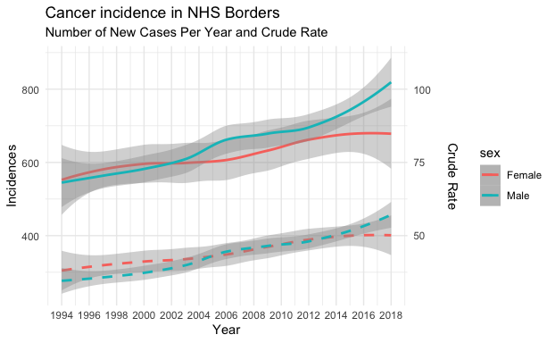

```r
#Will need to understand and be able to explain how the geom_smooth is working in this particular case. Also, will be intesting to address exactly why the incidents seem to flutuate up and down to such a large ever year or two.
borders_data %>%
  filter(cancer_site == "All cancer types",
         sex != "All") %>%
ggplot() +
  aes(x = year, y = incidences_all_ages, colour = sex) +
  geom_smooth(linetype = "dashed") +
  geom_smooth(aes(x = year, y = crude_rate)) +
  scale_x_continuous(breaks = seq(1994, 2018, by = 2 )) +
  scale_y_continuous(sec.axis = sec_axis(~./8, name = "Crude Rate\n")) +
  labs(x = "Year",
       y = "Incidences",
       title = "Cancer incidence in NHS Borders",
       subtitle = "Number of New Cases Per Year and Crude Rate") +
  #Can't work out why the legend below isn't working
  scale_fill_discrete(name = "Sex", labels = c("a", "b")) +
  theme_minimal()
```

2. Figure 4. Most common 20 cancers in Scotland in 2016 for females and males (ordered by total for all persons)

```r
#Could have worked out a different way to arrange by total and then mutated this into a new column rather than combining the male and female figures afterwards.
chart_2_borders_data <-
borders_data %>%
  filter(year == 2016,
         sex != "All",
         cancer_site != "All cancer types"
        ) %>%
  mutate(name_and_code = str_c(cancer_site, " (", cancer_site_icd10code, ")")) %>%
  mutate(name_and_code = str_remove(name_and_code, "ICD-10 "))


chart_2_borders_data
```

[output not shown]

```r
#Think this is right but can always check when we make the graph
chart_2_border_scot_top_20 <-
chart_2_borders_data %>%
  filter(cancer_site %in% c("Trachea, bronchus and lung",
                            "Breast",
                            "Colorectal cancer",
                            "Prostate",
                            "Malignant melanoma of the skin",
                            "Head and neck",
                            "Non-Hodgkin lymphoma",
                            "Kidney",
                            "Bladder",
                            "Oesophagus",
                            "Pancreas",
                            "Corpus uteri",
                            "Stomach",
                            "Leukaemias",
                            "Ovary",
                            "Liver and intrahepatic bile ducts",
                            "Multiple myeloma and malignant plasma cell neoplasms",
                            "Malig brain ca (incl pit. gland, cranio. duct, pineal gland)",
                            "Cervix uteri",
                            "Thyroid")) %>%

  mutate(cancer_site = factor(cancer_site, levels = c("Trachea, bronchus and lung",
                            "Breast",
                            "Colorectal cancer",
                            "Prostate",
                            "Malignant melanoma of the skin",
                            "Head and neck",
                            "Non-Hodgkin lymphoma",
                            "Kidney",
                            "Bladder",
                            "Oesophagus",
                            "Pancreas",
                            "Corpus uteri",
                            "Stomach",
                            "Leukaemias",
                            "Ovary",
                            "Liver and intrahepatic bile ducts",
                            "Multiple myeloma and malignant plasma cell neoplasms",
                            "Malig brain ca (incl pit. gland, cranio. duct, pineal gland)",
                            "Cervix uteri",
                            "Thyroid"))) %>%

  mutate(cancer_site = recode(cancer_site,
                              "Multiple myeloma and malignant plasma cell neoplasms" = "Multiple myeloma, mal plasma cell neo",
                              "Malig brain ca (incl pit. gland, cranio. duct, pineal gland)" = "Brain and other CNS"))


chart_2_border_scot_top_20
```

[output not shown]

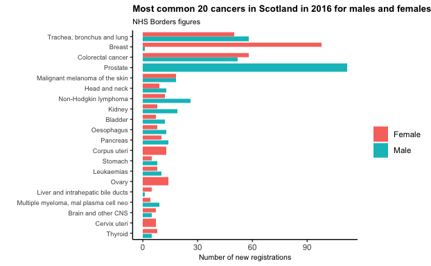

```r
#Need to find a way to flip the female and male dodges. Also, should rename a couple of the cancer_sites - DONE BOTH
chart_2_border_scot_top_20 %>%
  ggplot() +
  aes(x = incidences_all_ages,
      y = reorder(cancer_site,
                  desc(cancer_site)),
                  fill = sex) +
  geom_col(position = position_dodge2(reverse = TRUE)) +
  labs(title = "Most common 20 cancers in Scotland in 2016 for males and females",
       subtitle = "NHS Borders figures",
       x = "Number of new registrations",
       y = "") +
  scale_fill_discrete(name = "") +
  theme_classic() +
  theme(axis.text.y = element_text(size = 7)) +
  theme(axis.title.x.bottom = element_text(size = 8)) +
  theme(plot.title = element_text(size = 10, face = 'bold')) +
  theme(plot.subtitle = element_text(size = 8))
```

```r
NA
NA
NA
NA
```

3. Figure 5. 10 year percentage change in incidence rate for 20 most common cancers in Scotland

```r
chart_3_borders_data <-
borders_data %>%
  filter(sex != "All",
         cancer_site != "All cancer types"
        ) %>%
  mutate(name_and_code = str_c(cancer_site, " (", cancer_site_icd10code, ")")) %>%
  mutate(name_and_code = str_remove(name_and_code, "ICD-10 "))


chart_3_borders_data
```

| hb | cancer_site_icd10code | cancer_site | sex | sex_qf | year | incidences_all_ages | crude_rate | crude_rate_lower95pc_confidence_interval | crude_rate_upper95pc_confidence_interval | easr | easr_lower95pc_confidence_interval | easr_lower95pc_confidence_interval_qf | easr_upper95pc_confidence_interval | easr_upper95pc_confidence_interval_qf | wasr | wasr_lower95pc_confidence_interval | wasr_lower95pc_confidence_interval_qf | wasr_upper95pc_confidence_interval | wasr_upper95pc_confidence_interval_qf | standardised_incidence_ratio | sir_lower95pc_confidence_interval | sir_upper95pc_confidence_interval | name_and_code |
| --- | --- | --- | --- | --- | --- | --- | --- | --- | --- | --- | --- | --- | --- | --- | --- | --- | --- | --- | --- | --- | --- | --- | --- |
| S08000016 | C67 | Bladder | Male | NA | 1994 | 11 | 21.777435 | 10.87121690 | 38.965846 | 24.288844 | NA | z | NA | z | 11.6044527 | NA | z | NA | z | 44.54688 | 22.2376424 | 79.70667 | Bladder (C67) |
| S08000016 | C67 | Bladder | Male | NA | 1995 | 23 | 45.266680 | 28.69519196 | 67.922245 | 55.080788 | 34.56597 | NA | 80.29807 | NA | 23.7785210 | 14.790411 | NA | 34.86608 | NA | 96.96973 | 61.4704935 | 145.50221 | Bladder (C67) |
| S08000016 | C67 | Bladder | Male | NA | 1996 | 30 | 59.043495 | 39.83639839 | 84.288261 | 74.538119 | 48.58193 | NA | 105.96119 | NA | 30.1070945 | 19.914848 | NA | 42.37211 | NA | 125.62786 | 84.7605882 | 179.34158 | Bladder (C67) |
| S08000016 | C67 | Bladder | Male | NA | 1997 | 18 | 35.373187 | 20.96439253 | 55.904886 | 40.934099 | NA | z | NA | z | 16.5961006 | NA | z | NA | z | 87.71426 | 51.9850279 | 138.62634 | Bladder (C67) |
| S08000016 | C67 | Bladder | Male | NA | 1998 | 12 | 23.555276 | 12.17135503 | 41.146327 | 28.696866 | NA | z | NA | z | 11.1892015 | NA | z | NA | z | 74.22822 | 38.3548057 | 129.66177 | Bladder (C67) |
| S08000016 | C67 | Bladder | Male | NA | 1999 | 16 | 31.418136 | 17.95817942 | 51.021085 | 37.174345 | NA | z | NA | z | 14.1592330 | NA | z | NA | z | 106.41786 | 60.8270038 | 172.81594 | Bladder (C67) |
| S08000016 | C67 | Bladder | Male | NA | 2000 | 14 | 27.395116 | 14.97716475 | 45.964349 | 32.516291 | NA | z | NA | z | 10.6259760 | NA | z | NA | z | 105.13863 | 57.4802683 | 176.40476 | Bladder (C67) |
| S08000016 | C67 | Bladder | Male | NA | 2001 | 14 | 27.201896 | 14.87152987 | 45.640160 | 35.883882 | NA | z | NA | z | 13.9803852 | NA | z | NA | z | 103.96617 | 56.8392707 | 174.43756 | Bladder (C67) |
| S08000016 | C67 | Bladder | Male | NA | 2002 | 10 | 19.277852 | 9.24447920 | 35.452656 | 21.664503 | NA | z | NA | z | 8.0743532 | NA | z | NA | z | 71.03005 | 34.0616707 | 130.62679 | Bladder (C67) |
| S08000016 | C67 | Bladder | Male | NA | 2003 | 17 | 32.508510 | 18.93740481 | 52.049273 | 41.146080 | NA | z | NA | z | 13.9150203 | NA | z | NA | z | 124.12793 | 72.3090958 | 198.74085 | Bladder (C67) |

[output cut: 990 more lines]

```r
chart_3_border_scot_top_20 <-
chart_3_borders_data %>%
  filter(cancer_site %in% c("Trachea, bronchus and lung",
                            "Breast",
                            "Colorectal cancer",
                            "Prostate",
                            "Malignant melanoma of the skin",
                            "Head and neck",
                            "Non-Hodgkin lymphoma",
                            "Kidney",
                            "Bladder",
                            "Oesophagus",
                            "Pancreas",
                            "Corpus uteri",
                            "Stomach",
                            "Leukaemias",
                            "Ovary",
                            "Liver and intrahepatic bile ducts",
                            "Multiple myeloma and malignant plasma cell neoplasms",
                            "Malig brain ca (incl pit. gland, cranio. duct, pineal gland)",
                            "Cervix uteri",
                            "Thyroid")) %>%

  mutate(cancer_site = factor(cancer_site, levels = c(
                            "Stomach",
                            "Leukaemias",
                            "Colorectal cancer",
                            "Trachea, bronchus and lung",
                            "Ovary",
                            "Oesophagus",
                            "Malig brain ca (incl pit. gland, cranio. duct, pineal gland)",
                            "Non-Hodgkin lymphoma",
                            "Prostate",
                            "Bladder",
                            "Breast",
                            "Multiple myeloma and malignant plasma cell neoplasms",
                            "Pancreas",
                            "Head and neck",
                            "Cervix uteri",
                            "Malignant melanoma of the skin",
                            "Corpus uteri",
                            "Kidney",
                            "Liver and intrahepatic bile ducts",
                            "Thyroid"))) %>%

  mutate(cancer_site = recode(cancer_site,
                              "Multiple myeloma and malignant plasma cell neoplasms" = "Multiple myeloma, mal plasma cell neo",
                              "Malig brain ca (incl pit. gland, cranio. duct, pineal gland)" = "Brain and other CNS"))


chart_3_border_scot_top_20
```

| hb | cancer_site_icd10code | cancer_site | sex | sex_qf | year | incidences_all_ages | crude_rate | crude_rate_lower95pc_confidence_interval | crude_rate_upper95pc_confidence_interval | easr | easr_lower95pc_confidence_interval | easr_lower95pc_confidence_interval_qf | easr_upper95pc_confidence_interval | easr_upper95pc_confidence_interval_qf | wasr | wasr_lower95pc_confidence_interval | wasr_lower95pc_confidence_interval_qf | wasr_upper95pc_confidence_interval | wasr_upper95pc_confidence_interval_qf | standardised_incidence_ratio | sir_lower95pc_confidence_interval | sir_upper95pc_confidence_interval | name_and_code |
| --- | --- | --- | --- | --- | --- | --- | --- | --- | --- | --- | --- | --- | --- | --- | --- | --- | --- | --- | --- | --- | --- | --- | --- |
| S08000016 | C67 | Bladder | Male | NA | 1994 | 11 | 21.777435 | 10.87121690 | 38.965846 | 24.288844 | NA | z | NA | z | 11.6044527 | NA | z | NA | z | 44.54688 | 22.2376424 | 79.70667 | Bladder (C67) |
| S08000016 | C67 | Bladder | Male | NA | 1995 | 23 | 45.266680 | 28.69519196 | 67.922245 | 55.080788 | 34.56597 | NA | 80.29807 | NA | 23.7785210 | 14.790411 | NA | 34.86608 | NA | 96.96973 | 61.4704935 | 145.50221 | Bladder (C67) |
| S08000016 | C67 | Bladder | Male | NA | 1996 | 30 | 59.043495 | 39.83639839 | 84.288261 | 74.538119 | 48.58193 | NA | 105.96119 | NA | 30.1070945 | 19.914848 | NA | 42.37211 | NA | 125.62786 | 84.7605882 | 179.34158 | Bladder (C67) |
| S08000016 | C67 | Bladder | Male | NA | 1997 | 18 | 35.373187 | 20.96439253 | 55.904886 | 40.934099 | NA | z | NA | z | 16.5961006 | NA | z | NA | z | 87.71426 | 51.9850279 | 138.62634 | Bladder (C67) |
| S08000016 | C67 | Bladder | Male | NA | 1998 | 12 | 23.555276 | 12.17135503 | 41.146327 | 28.696866 | NA | z | NA | z | 11.1892015 | NA | z | NA | z | 74.22822 | 38.3548057 | 129.66177 | Bladder (C67) |
| S08000016 | C67 | Bladder | Male | NA | 1999 | 16 | 31.418136 | 17.95817942 | 51.021085 | 37.174345 | NA | z | NA | z | 14.1592330 | NA | z | NA | z | 106.41786 | 60.8270038 | 172.81594 | Bladder (C67) |
| S08000016 | C67 | Bladder | Male | NA | 2000 | 14 | 27.395116 | 14.97716475 | 45.964349 | 32.516291 | NA | z | NA | z | 10.6259760 | NA | z | NA | z | 105.13863 | 57.4802683 | 176.40476 | Bladder (C67) |
| S08000016 | C67 | Bladder | Male | NA | 2001 | 14 | 27.201896 | 14.87152987 | 45.640160 | 35.883882 | NA | z | NA | z | 13.9803852 | NA | z | NA | z | 103.96617 | 56.8392707 | 174.43756 | Bladder (C67) |
| S08000016 | C67 | Bladder | Male | NA | 2002 | 10 | 19.277852 | 9.24447920 | 35.452656 | 21.664503 | NA | z | NA | z | 8.0743532 | NA | z | NA | z | 71.03005 | 34.0616707 | 130.62679 | Bladder (C67) |
| S08000016 | C67 | Bladder | Male | NA | 2003 | 17 | 32.508510 | 18.93740481 | 52.049273 | 41.146080 | NA | z | NA | z | 13.9150203 | NA | z | NA | z | 124.12793 | 72.3090958 | 198.74085 | Bladder (C67) |

[output cut: 890 more lines]

```r
NA
```

```r
chart_3_selection <-
chart_3_border_scot_top_20 %>%
  select(cancer_site, sex, year, incidences_all_ages, crude_rate, easr, wasr, cancer_site_icd10code)

chart_3_selection
```

| cancer_site | sex | year | incidences_all_ages | crude_rate | easr | wasr | cancer_site_icd10code |
| --- | --- | --- | --- | --- | --- | --- | --- |
| Bladder | Male | 1994 | 11 | 21.777435 | 24.288844 | 11.6044527 | C67 |
| Bladder | Male | 1995 | 23 | 45.266680 | 55.080788 | 23.7785210 | C67 |
| Bladder | Male | 1996 | 30 | 59.043495 | 74.538119 | 30.1070945 | C67 |
| Bladder | Male | 1997 | 18 | 35.373187 | 40.934099 | 16.5961006 | C67 |
| Bladder | Male | 1998 | 12 | 23.555276 | 28.696866 | 11.1892015 | C67 |
| Bladder | Male | 1999 | 16 | 31.418136 | 37.174345 | 14.1592330 | C67 |
| Bladder | Male | 2000 | 14 | 27.395116 | 32.516291 | 10.6259760 | C67 |
| Bladder | Male | 2001 | 14 | 27.201896 | 35.883882 | 13.9803852 | C67 |
| Bladder | Male | 2002 | 10 | 19.277852 | 21.664503 | 8.0743532 | C67 |
| Bladder | Male | 2003 | 17 | 32.508510 | 41.146080 | 13.9150203 | C67 |

[output cut: 890 more lines]

```r
#Thinking I'll pivot wider here so I can get a quick figure for each of the rates and incidence. Actually, just realized, I only need years 2006 and 2016.
chart_3_2006_2016 <-
chart_3_selection %>%
  filter(year %in% c(2006, 2016))

chart_3_2006_2016
```

| cancer_site | sex | year | incidences_all_ages | crude_rate | easr | wasr | cancer_site_icd10code |
| --- | --- | --- | --- | --- | --- | --- | --- |
| Bladder | Male | 2006 | 10 | 18.630647 | 20.187097 | 7.6637201 | C67 |
| Bladder | Male | 2016 | 12 | 21.615390 | 21.167075 | 5.8943598 | C67 |
| Bladder | Female | 2006 | 5 | 8.743552 | 7.785474 | 3.6275756 | C67 |
| Bladder | Female | 2016 | 7 | 11.861592 | 9.340569 | 2.7214930 | C67 |
| Brain and other CNS | Male | 2006 | 5 | 9.315324 | 9.287567 | 4.2087724 | C70-C72, C75.1-C75.3 |
| Brain and other CNS | Male | 2016 | 5 | 9.006413 | 7.222709 | 3.7847835 | C70-C72, C75.1-C75.3 |
| Brain and other CNS | Female | 2006 | 2 | 3.497421 | 3.163504 | 2.3523093 | C70-C72, C75.1-C75.3 |
| Brain and other CNS | Female | 2016 | 7 | 11.861592 | 9.110324 | 4.0724516 | C70-C72, C75.1-C75.3 |
| Breast | Male | 2006 | 0 | 0.000000 | 0.000000 | 0.0000000 | C50 |
| Breast | Male | 2016 | 1 | 1.801283 | 1.266114 | 0.6906077 | C50 |

[output cut: 62 more lines]

```r
NA
```

```r
chart_3_pivot <-
chart_3_2006_2016 %>%
  pivot_wider(names_from = year,
              values_from = c(incidences_all_ages, crude_rate, easr, wasr))

chart_3_pivot
```

| cancer_site | sex | cancer_site_icd10code | incidences_all_ages_2006 | incidences_all_ages_2016 | crude_rate_2006 | crude_rate_2016 | easr_2006 | easr_2016 | wasr_2006 | wasr_2016 |
| --- | --- | --- | --- | --- | --- | --- | --- | --- | --- | --- |
| Bladder | Male | C67 | 10 | 12 | 18.630647 | 21.615390 | 20.187097 | 21.167075 | 7.6637201 | 5.8943598 |
| Bladder | Female | C67 | 5 | 7 | 8.743552 | 11.861592 | 7.785474 | 9.340569 | 3.6275756 | 2.7214930 |
| Brain and other CNS | Male | C70-C72, C75.1-C75.3 | 5 | 5 | 9.315324 | 9.006413 | 9.287567 | 7.222709 | 4.2087724 | 3.7847835 |
| Brain and other CNS | Female | C70-C72, C75.1-C75.3 | 2 | 7 | 3.497421 | 11.861592 | 3.163504 | 9.110324 | 2.3523093 | 4.0724516 |
| Breast | Male | C50 | 0 | 1 | 0.000000 | 1.801283 | 0.000000 | 1.266114 | 0.0000000 | 0.6906077 |
| Breast | Female | C50 | 68 | 98 | 118.912302 | 166.062290 | 106.711169 | 143.909531 | 52.7180718 | 83.1065612 |
| Colorectal cancer | Male | C18-C20 | 43 | 52 | 80.111784 | 93.666691 | 87.413210 | 86.249055 | 33.2780368 | 34.1937788 |
| Colorectal cancer | Female | C18-C20 | 59 | 58 | 103.173909 | 98.281764 | 93.527204 | 81.376236 | 40.0686382 | 37.3381365 |
| Cervix uteri | Female | C53 | 6 | 7 | 10.492262 | 11.861592 | 10.455037 | 10.681218 | 7.3848975 | 8.4237837 |
| Corpus uteri | Female | C54 | 3 | 13 | 5.246131 | 22.028671 | 4.985291 | 17.271937 | 2.9180124 | 6.5575889 |

[output cut: 26 more lines]

```r
chart_3_pivot_and_diff <-
chart_3_pivot %>%
  mutate(crude_ten_year_diff = crude_rate_2016 - crude_rate_2006) %>%
  mutate(incid_ten_year_diff = incidences_all_ages_2016 - incidences_all_ages_2006) %>%
  mutate(easr_ten_year_diff = easr_2016 - easr_2006) %>%
  mutate(wasr_ten_year_diff = wasr_2016 - wasr_2006)

chart_3_pivot_and_diff
```

| cancer_site | sex | cancer_site_icd10code | incidences_all_ages_2006 | incidences_all_ages_2016 | crude_rate_2006 | crude_rate_2016 | easr_2006 | easr_2016 | wasr_2006 | wasr_2016 | crude_ten_year_diff | incid_ten_year_diff | easr_ten_year_diff | wasr_ten_year_diff |
| --- | --- | --- | --- | --- | --- | --- | --- | --- | --- | --- | --- | --- | --- | --- |
| Bladder | Male | C67 | 10 | 12 | 18.630647 | 21.615390 | 20.187097 | 21.167075 | 7.6637201 | 5.8943598 | 2.9847427 | 2 | 0.9799777 | -1.76936026 |
| Bladder | Female | C67 | 5 | 7 | 8.743552 | 11.861592 | 7.785474 | 9.340569 | 3.6275756 | 2.7214930 | 3.1180405 | 2 | 1.5550944 | -0.90608259 |
| Brain and other CNS | Male | C70-C72, C75.1-C75.3 | 5 | 5 | 9.315324 | 9.006413 | 9.287567 | 7.222709 | 4.2087724 | 3.7847835 | -0.3089111 | 0 | -2.0648581 | -0.42398887 |
| Brain and other CNS | Female | C70-C72, C75.1-C75.3 | 2 | 7 | 3.497421 | 11.861592 | 3.163504 | 9.110324 | 2.3523093 | 4.0724516 | 8.3641715 | 5 | 5.9468193 | 1.72014232 |
| Breast | Male | C50 | 0 | 1 | 0.000000 | 1.801283 | 0.000000 | 1.266114 | 0.0000000 | 0.6906077 | 1.8012825 | 1 | 1.2661142 | 0.69060773 |
| Breast | Female | C50 | 68 | 98 | 118.912302 | 166.062290 | 106.711169 | 143.909531 | 52.7180718 | 83.1065612 | 47.1499881 | 30 | 37.1983625 | 30.38848938 |
| Colorectal cancer | Male | C18-C20 | 43 | 52 | 80.111784 | 93.666691 | 87.413210 | 86.249055 | 33.2780368 | 34.1937788 | 13.5549068 | 9 | -1.1641546 | 0.91574195 |
| Colorectal cancer | Female | C18-C20 | 59 | 58 | 103.173909 | 98.281764 | 93.527204 | 81.376236 | 40.0686382 | 37.3381365 | -4.8921456 | -1 | -12.1509678 | -2.73050169 |
| Cervix uteri | Female | C53 | 6 | 7 | 10.492262 | 11.861592 | 10.455037 | 10.681218 | 7.3848975 | 8.4237837 | 1.3693302 | 1 | 0.2261807 | 1.03888616 |
| Corpus uteri | Female | C54 | 3 | 13 | 5.246131 | 22.028671 | 4.985291 | 17.271937 | 2.9180124 | 6.5575889 | 16.7825402 | 10 | 12.2866455 | 3.63957651 |

[output cut: 26 more lines]

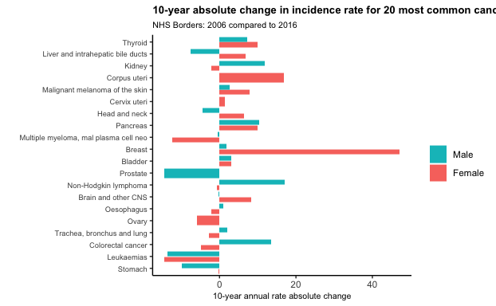

```r
#Had a bit of trouble with directly comparing this one to the one in the report. Because of the relatively low numbers of new incidents among certain cancers, the percentage change of rate was throwing up some highly misleading results (anywhere between -150 to 340, not including the one example of infinity). It would be interesting to see what figures the original graph actually refers to. Maybe, if there is spare time, we can plot it. However, instead, I decided to go for two graphs that although not directly comparable, certainly provide a better insight than the aforementioned graph.

#The first is the straight up difference in crude rate, defined as

#"The number of cases divided by the population. The crude rate does not
#attempt to adjust for differences in age and sex structures between
#different populations (see European age-standardised rate below).
#Typically expressed as the number of cases per 100,000 population."

chart_3_pivot_and_diff %>%
  ggplot() +
  aes(x = crude_ten_year_diff,
      y = cancer_site,
      fill = sex) +
  geom_col(position = position_dodge2(reverse = FALSE)) +
  scale_x_continuous(breaks = seq(from = -20, to = 60, by = 20)) +
    labs(title = "10-year absolute change in incidence rate for 20 most common cancers in Scotland",
         subtitle = "NHS Borders: 2006 compared to 2016",
      x = "10-year annual rate absolute change",
       y = "") +
  scale_fill_discrete(name = "", breaks = c("Male", "Female")) +
  theme_classic() +
  theme(axis.text.y = element_text(size = 7)) +
  theme(axis.title.x.bottom = element_text(size = 8)) +
  theme(plot.title = element_text(size = 10, face = 'bold')) +
  theme(plot.subtitle = element_text(size = 8))
```

```r
NA
NA
```

```r
#The second is simply the change in annual incidences, which after doing it I realise is just pretty much to same as the above.

chart_3_pivot_and_diff %>%
  ggplot() +
    aes(x = incid_ten_year_diff,
      y = cancer_site,
      fill = sex) +
  geom_col(position = position_dodge2(reverse = FALSE)) +
  labs(x = "10-year annual rate absolute change",
       y = "") +
  theme(axis.text.y = element_text(size = 7))
```

[output not shown]

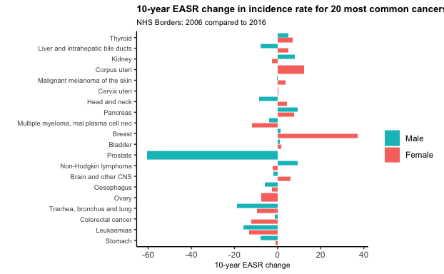

```r
chart_3_pivot_and_diff %>%
  ggplot() +
  aes(x = easr_ten_year_diff,
      y = cancer_site,
      fill = sex) +
  geom_col(position = position_dodge2(reverse = FALSE)) +
    labs(title = "10-year EASR change in incidence rate for 20 most common cancers in Scotland",
         subtitle = "NHS Borders: 2006 compared to 2016",
      x = "10-year EASR change",
       y = "") +
  scale_fill_discrete(name = "", breaks = c("Male", "Female")) +
  theme_classic() +
  theme(axis.text.y = element_text(size = 7)) +
  theme(axis.title.x.bottom = element_text(size = 8)) +
  theme(plot.title = element_text(size = 10, face = 'bold')) +
  theme(plot.subtitle = element_text(size = 8))
```

```r
NA
```

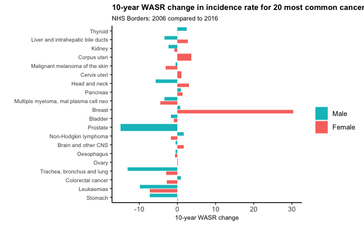

```r
chart_3_pivot_and_diff %>%
  ggplot() +
  aes(x = wasr_ten_year_diff,
      y = cancer_site,
      fill = sex) +
  geom_col(position = position_dodge2(reverse = FALSE)) +
    labs(title = "10-year WASR change in incidence rate for 20 most common cancers in Scotland",
         subtitle = "NHS Borders: 2006 compared to 2016",
      x = "10-year WASR change",
       y = "") +
  scale_fill_discrete(name = "", breaks = c("Male", "Female")) +
  theme_classic() +
  theme(axis.text.y = element_text(size = 7)) +
  theme(axis.title.x.bottom = element_text(size = 8)) +
  theme(plot.title = element_text(size = 10, face = 'bold')) +
  theme(plot.subtitle = element_text(size = 8))
```

```r
NA
```